# Part II - States and Occupation subgroups with high loan demand.

## by Jennifer Orji

## Investigation Overview

> Are you an advertisement agency or do you offer financial services and you want to understand the trend to determine what month of the year has high influx of loan seekers and how they vary by location and occupation?. Join me as we use visualization to answer these questions. The main features of interest are; Loan Origination Month, BorrowerState and Occupation. additional features used include; Loan Original Amount, Stated Monthly Income and Prosper Score among others.

## Dataset Overview

> The dataset contains almost 140,000 rows and 81 columns. A subset of rhe dataset was created and cleaned of inconsistencies and missing values.

## Distribution of Loan Original Amount among the states.

> There are spikes in loan amount in states like New Hampshire, Washington DC,Alaska, Maryland, Massachusetts e.t.c.This means that compared to other states, these aforementioned states have high financial demands.

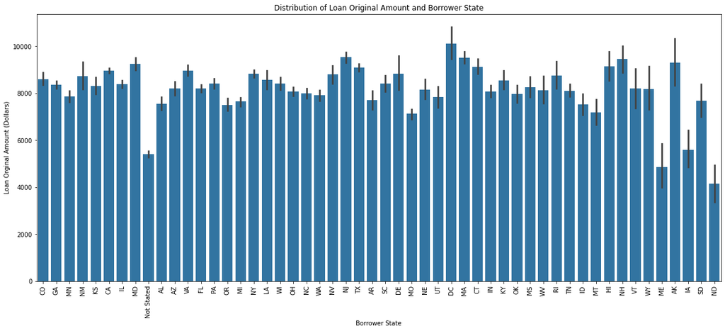

## Distribution of Loan Original Amount among the Occupation Subgroups.

> There are spikes in loan amount in occupations pharmacy, judge, principal, pilot, executive e.t.c showing high demand.

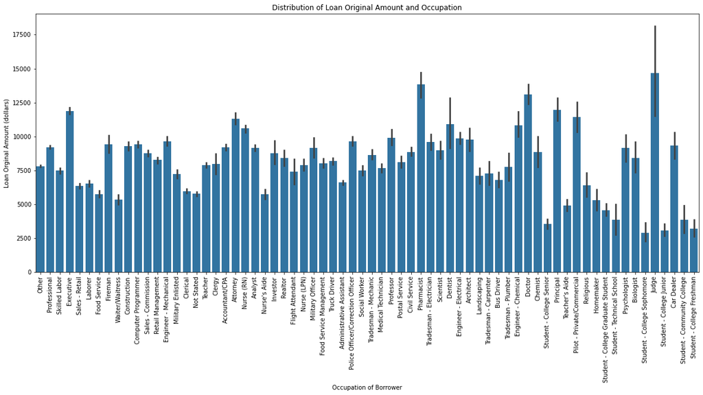

## How Loan Amount vary across states in December, October and January; then February, November and August.

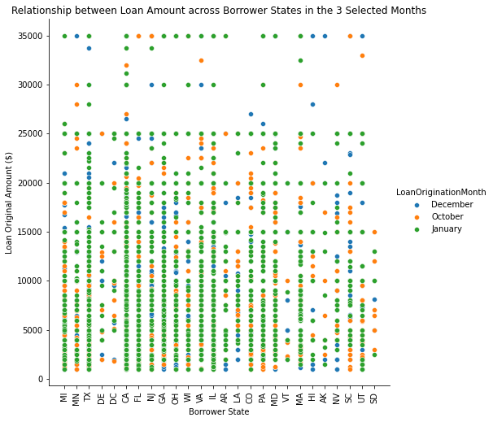

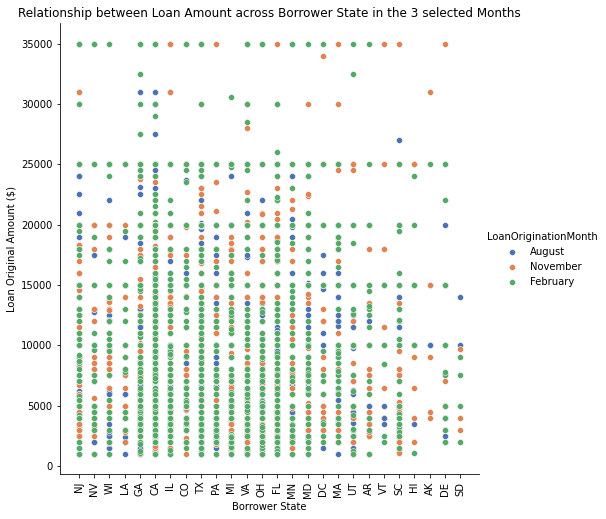

## How Loan Amount vary across Occupations in December, October and January; then February, November and August.

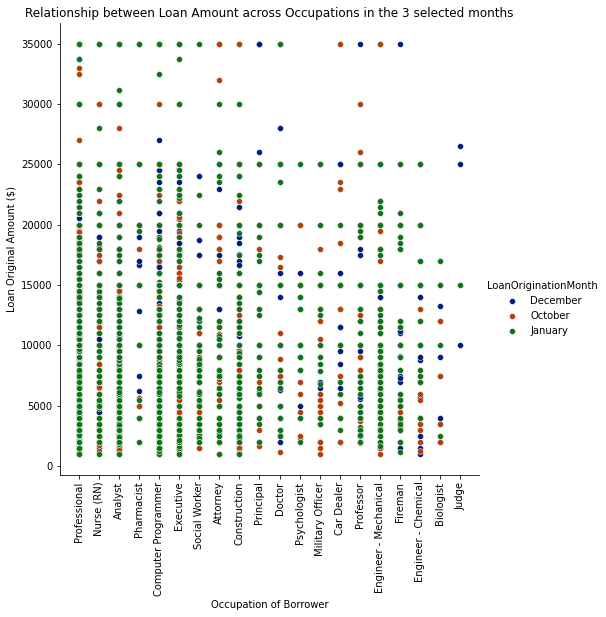

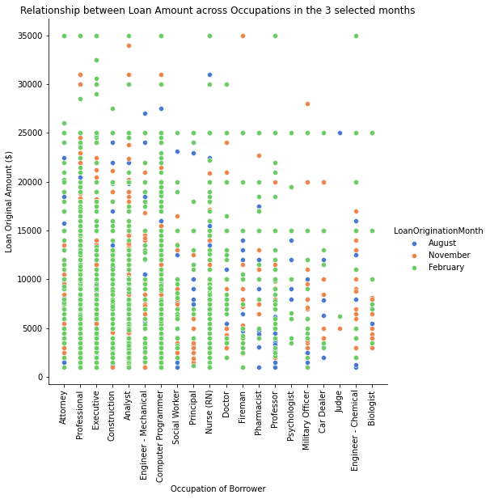

## (How does Loan Amount vary across Loan Origination Month and Loan Term¶)

> There is a positive relationship between loan amount and loan term across the months. the higher the loan amount, the higher the loan term.

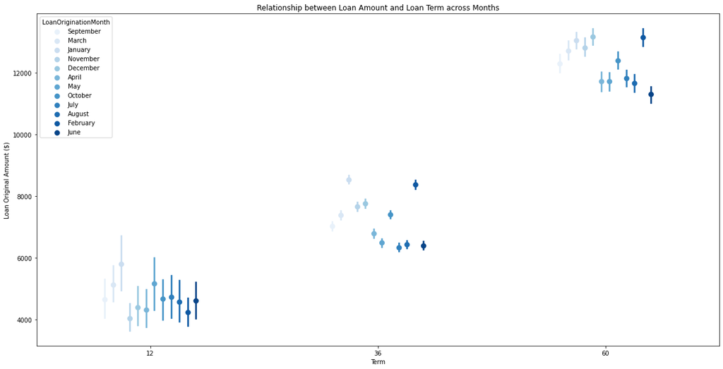

#### With these information, we can make decisions as to when best in a year send targeted ads to certain states and professions to maximize sales and customer retention.